# Case study: Birthday data

G. Riutort-Mayol, M.R. Andersen, P.C. Burkner, A. Solin and A. Vehtari

2021-06-01.

## Load packages

```r
library(rstan)
library(cmdstanr)
options(mc.cores = parallel::detectCores())
rstan_options(auto_write = FALSE)
library(posterior)
library(bayesplot)
library(ggplot2)
library(loo)
library(latex2exp)
```

## Data

```r
data <- read.csv(file="../births_usa_1969.csv")
str(data)
```

```
## 'data.frame':    7305 obs. of  8 variables:
##  $ year        : int  1969 1969 1969 1969 1969 1969 1969 1969 1969 1969 ...
##  $ month       : int  1 1 1 1 1 1 1 1 1 1 ...
##  $ day         : int  1 2 3 4 5 6 7 8 9 10 ...
##  $ births      : int  8486 9002 9542 8960 8390 9560 9738 9734 9434 10042 ...
##  $ day_of_year : int  1 2 3 4 5 6 7 8 9 10 ...
##  $ day_of_week : int  3 4 5 6 7 1 2 3 4 5 ...
##  $ id          : int  1 2 3 4 5 6 7 8 9 10 ...
##  $ day_of_year2: int  1 2 3 4 5 6 7 8 9 10 ...
```

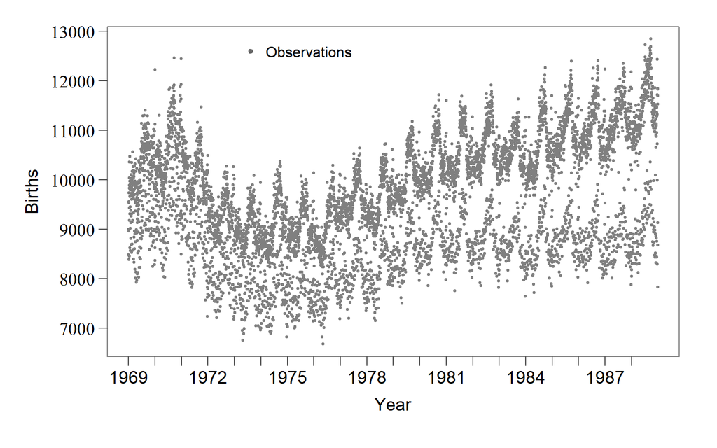

```r
par(mai=c(1.02,1.2,0.3,0.42))

ind <- data$id
births <- data$births
labels_at = aggregate(data, by=list(data$year), FUN=min)$id

plot(ind, births[ind], type="p", pch=20, bg=grey(0.4), cex=0.6, col=grey(0.5), xlab="", ylab="", lwd=1, mgp=c(3.5, 1, 0), frame.plot=TRUE, yaxs="r", cex.axis=1.2, cex.lab=1.2, las=1, xaxt="n", yaxt="n", fg=grey(0.5), family="serif")
axis(1, at = labels_at, c("1969","1970","1971","1972","1973","1974","1975","1976","1977","1978","1979","1980","1981","1982","1983","1984","1985","1986","1987","1988"), lty=1, mgp=c(3, 0.7, 0), las=1, cex.axis=1.2, font=1, col=grey(0.5), col.ticks=grey(0.3), family="")
axis(2, lty=1, mgp=c(3, 0.7, 0), las=1, cex.axis=1.2, font=5, col=grey(0.5), col.ticks=grey(0.3))
title(xlab="Year", mgp=c(2.2, 1, 0), cex.lab=1.2, las=1)
title(ylab="Births", mgp=c(3.7, 0.7, 0), cex.lab=1.2, las=1)
legend("topleft",inset=c(0.22,0.02),legend=c("Observations"), col=grey(0.4), lty=NA, pch=20, lwd=1, cex=1, xpd=TRUE, bty="n", x.intersp=0.1, text.font=1)
```

## HSGP modeling and fitting

Input vector

```r
x <- scale(data$id[], center=TRUE, scale=TRUE)
```

Output vector

```r
y <- scale(data$births[], center=TRUE, scale=TRUE)
```

Standard deviation and mean of the output

```r
std_y <- attr(y,"scaled:scale")
m_y <- attr(y,"scaled:center")
```

Standard deviation of the input

```r
std_x <- attr(x,"scaled:scale")
```

Year and week periods

```r
period_year <- 365.25/std_x
period_week <- 7/std_x
```

`Day of the year2` is a variable that indicates the correspondence between all the days with the days of a leap-year

```r
day_of_year2 <- data$day_of_year2
```

### HSGP tunnig factors

Number of basis functions $M$ for the smooth trend function $f_1$

```r
M_f1 <- 40
```

Boundary factor $c$ for $f_1$

```r
c_f1 <- 1.5
```

Number of basis functions $J$ for year effects function $f_2$

```r
J_f2 <- 20
```

Number of basis functions $J$ for the week effects function $f_3$

```r
J_f3 <- 7
```

### Data to be passed to Stan

```r
standata <- list(M_f1= M_f1,
                 c_f1= c_f1,
                 J_f2= J_f2,
                 J_f3= J_f3,
                 x= x[,1],
                 y= y[,1],
                 N= length(x),
                 period_year= period_year,
                 period_week= period_week,
                 day_of_year2= day_of_year2
)
```

### Stan model

```
//saved in 'stancode_def.stan'
functions {
  vector diagSPD_EQ(real gpscale, real lscale, real L, int M) {
    return sqrt((gpscale^2) * sqrt(2*pi()) * lscale * exp(-0.5*(lscale*pi()/2/L)^2 * linspaced_vector(M, 1, M)^2));
  }
  vector diagSPD_periodic(real gpscale, real lscale, int M) {
    real a = 1/lscale^2;
    int one_to_M[M];
    for (m in 1:M) one_to_M[m] = m;
    vector[M] q = sqrt(gpscale^2 * 2 / exp(a) * to_vector(modified_bessel_first_kind(one_to_M, a)));
    return append_row(q,q);
  }
  matrix PHI_EQ(int N, int M, real L, vector x) {
    return sin(diag_post_multiply(rep_matrix(pi()/(2*L) * (x+L), M), linspaced_vector(M, 1, M)))/sqrt(L);
  }
  matrix PHI_periodic(int N, int M, real w0, vector x) {
    matrix[N,M] mw0x = diag_post_multiply(rep_matrix(w0*x, M), linspaced_vector(M, 1, M));
    return append_col(cos(mw0x), sin(mw0x));
  }
}
data {
    real c_f1;                  //boundary value for function 1
    int<lower=1> M_f1;          //num basis functions for function 1
    int<lower=-1> J_f2;         //num cosine and sinu functions for function 3
    int<lower=-1> J_f3;         //num cosine and sinu functions for function 4
    int<lower=1> N;             //num observations
    vector[N] x;                //input vector
    vector[N] y;                //target vector
    real period_year;           //period of the year
    real period_week;           //period of the week
    int day_of_year2[N];        //day of the year inside a leap-year
}
transformed data {
    real L_f1= c_f1*max(fabs(x));
    //Basis functions for f1, f2 and f3
    matrix[N,M_f1] PHI_f1 = PHI_EQ(N, M_f1, L_f1, x);
    matrix[N,2*J_f2] PHI_f2 = PHI_periodic(N, J_f2, 2*pi()/period_year, x);
    matrix[N,2*J_f3] PHI_f3 = PHI_periodic(N, J_f3, 2*pi()/period_week, x);
}
parameters {
```

[output cut: 43 more lines]

```
    //t-student prior for special days effects
    f4 ~ student_t(1, 0, sigma_f4);
    sigma_f4 ~ normal(0, 0.1);
    //
    f= intercept + f1 + f2 + f3 + f4[day_of_year2];
    target += normal_lpdf(y | f, noise);
}
generated quantities{
  vector[N] y_rep;
  vector[N] log_lik;
  for(n in 1:N){
    y_rep[n] = normal_rng(f[n], noise);
    log_lik[n] = normal_lpdf(y[n] | f[n], noise);
  }
}
```

### Model sampling

Compiling the model

```r
birthday_mod <- cmdstanr::cmdstan_model(stan_file = "stancode_def.stan")
```

Model sampling (using `cmdstanr` package)

```r
fit <- birthday_mod$sample(data= standata, iter_warmup=200, iter_sampling=200, chains=4, thin=4, init=0.5, adapt_delta=0.9, save_warmup=FALSE)
```

```
## Running MCMC with 4 chains, at most 6 in parallel...
##
## Chain 1 Iteration:   1 / 400 [  0%]  (Warmup)
## Chain 2 Iteration:   1 / 400 [  0%]  (Warmup)
## Chain 3 Iteration:   1 / 400 [  0%]  (Warmup)
## Chain 4 Iteration:   1 / 400 [  0%]  (Warmup)
## Chain 2 Iteration: 100 / 400 [ 25%]  (Warmup)
## Chain 1 Iteration: 100 / 400 [ 25%]  (Warmup)
## Chain 3 Iteration: 100 / 400 [ 25%]  (Warmup)
## Chain 4 Iteration: 100 / 400 [ 25%]  (Warmup)
## Chain 2 Iteration: 200 / 400 [ 50%]  (Warmup)
## Chain 2 Iteration: 201 / 400 [ 50%]  (Sampling)
## Chain 3 Iteration: 200 / 400 [ 50%]  (Warmup)
## Chain 4 Iteration: 200 / 400 [ 50%]  (Warmup)
## Chain 3 Iteration: 201 / 400 [ 50%]  (Sampling)
## Chain 4 Iteration: 201 / 400 [ 50%]  (Sampling)
## Chain 1 Iteration: 200 / 400 [ 50%]  (Warmup)
## Chain 1 Iteration: 201 / 400 [ 50%]  (Sampling)
## Chain 2 Iteration: 300 / 400 [ 75%]  (Sampling)
## Chain 3 Iteration: 300 / 400 [ 75%]  (Sampling)
## Chain 4 Iteration: 300 / 400 [ 75%]  (Sampling)
## Chain 1 Iteration: 300 / 400 [ 75%]  (Sampling)
## Chain 2 Iteration: 400 / 400 [100%]  (Sampling)
## Chain 2 finished in 3030.1 seconds.
## Chain 3 Iteration: 400 / 400 [100%]  (Sampling)
## Chain 3 finished in 3087.6 seconds.
## Chain 4 Iteration: 400 / 400 [100%]  (Sampling)
## Chain 4 finished in 3094.2 seconds.
## Chain 1 Iteration: 400 / 400 [100%]  (Sampling)
## Chain 1 finished in 3097.7 seconds.
##
## All 4 chains finished successfully.
## Mean chain execution time: 3077.4 seconds.
## Total execution time: 3098.0 seconds.
```

Conversion of the model output from ‘cmdstanr’ package to ‘rstan’ package. This uses the output CSV files saved at a temporary directory. If you want a permament saving of these files at a local directory use `cmdstanr::fit$save_output_files()`

```r
fit_rstan <- rstan::read_stan_csv(fit$output_files())
```

## Model diagnosis

Posterior samples

```r
posterior <- as.array(fit_rstan)
```

Log posterior density

```r
lp <- log_posterior(fit_rstan)
```

Values for parameters of the performance of NUTS sampler

```r
np <- nuts_params(fit_rstan)
```

Draws

```r
draws <- extract(fit_rstan)
```

Summaries of variable estimates

```r
param = c("intercept","lscale[1]","lscale[2]","lscale[3]","gpscale[1]","gpscale[2]","gpscale[3]","noise","sigma_f4")
summary(fit_rstan, pars = param, probs = c(0.025, 0.5, 0.975), digits_summary = 4)$summary
```

```
##                   mean      se_mean          sd         2.5%        50%
## intercept  0.009706591 0.0123897762 0.184868512 -0.351886650 0.02560050
## lscale[1]  0.144917680 0.0011366052 0.013990283  0.118944625 0.14494050
## lscale[2]  0.226467955 0.0019642346 0.019341887  0.189995200 0.22501200
## lscale[3]  1.567790900 0.0574997132 0.657019590  0.468438325 1.52140000
## gpscale[1] 0.613158060 0.0136144034 0.141751346  0.395758600 0.58598650
## gpscale[2] 0.298885390 0.0072158012 0.049338878  0.221792325 0.29217600
## gpscale[3] 2.822341605 0.1938857387 2.351913760  0.684412925 2.07008500
## noise      0.292226875 0.0001680461 0.002487306  0.286875725 0.29215600
## sigma_f4   0.012730693 0.0004114989 0.002524430  0.008261745 0.01264725
##                 97.5%     n_eff      Rhat
## intercept  0.36337855 222.63783 0.9947568
## lscale[1]  0.17291470 151.50736 0.9971932
## lscale[2]  0.26493170  96.96410 1.0426560
## lscale[3]  3.01079325 130.56455 0.9962699
## gpscale[1] 0.95775485 108.40696 1.0111391
## gpscale[2] 0.40612475  46.75299 1.0819564
## gpscale[3] 9.57234725 147.14688 0.9899702
## noise      0.29717495 219.07934 1.0032262
## sigma_f4   0.01798747  37.63478 1.0915283
```

Simulation chains for the variables after warmup

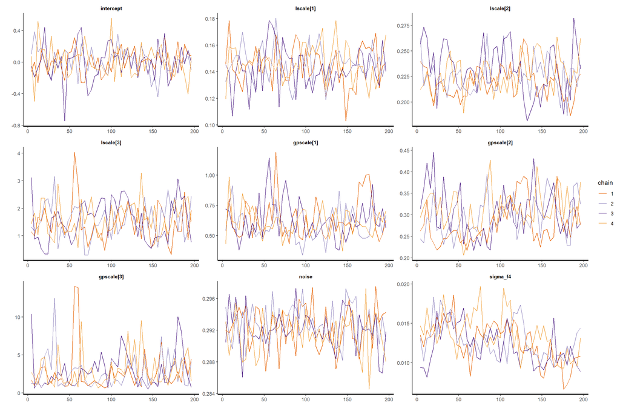

```r
traceplot(fit_rstan, pars = param, include = TRUE, unconstrain = FALSE, inc_warmup = FALSE, window = NULL, nrow = NULL, ncol = NULL)
```

Bivariate samples plots

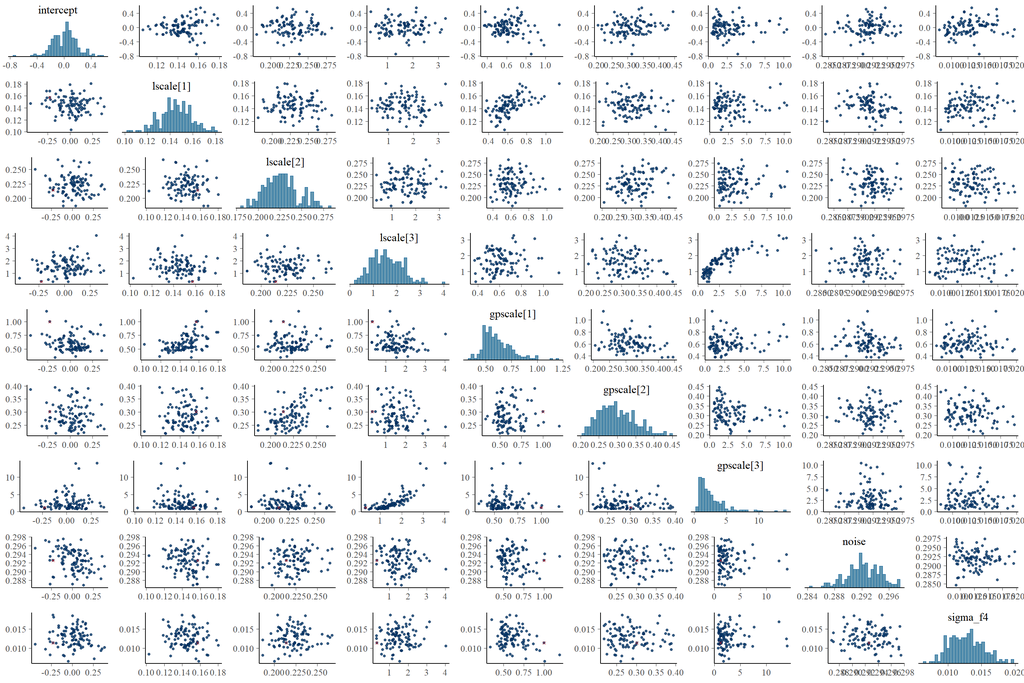

```r
mcmc_pairs(posterior, np= np, pars= param, off_diag_args= list(size = 1))
```

Autocorrelation plots

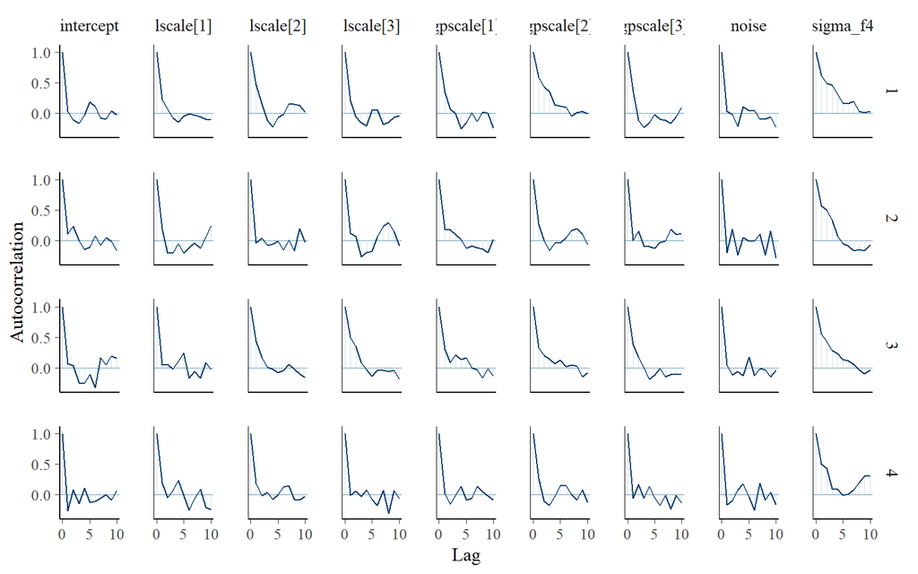

```r
mcmc_acf(posterior, pars = param, lags = 10)
```

Posterior predictive checks

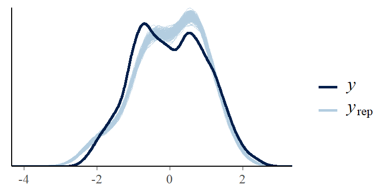

```r
ppc_dens_overlay(y[,1], draws$y_rep)
```

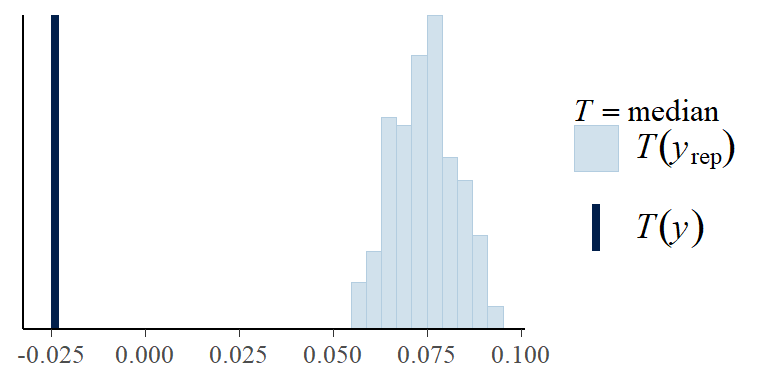

```r
ppc_stat(y[,1], draws$y_rep, stat = "median")
```

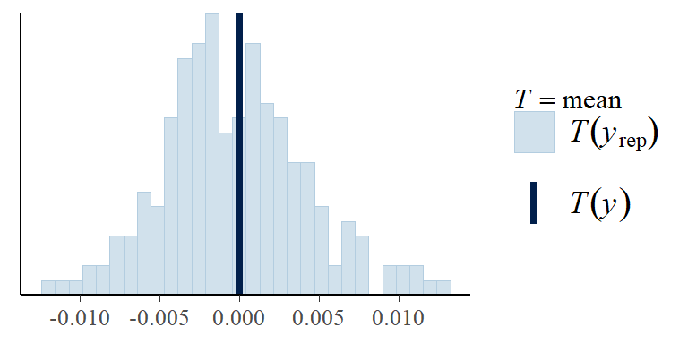

```r
ppc_stat(y[,1], draws$y_rep, stat = "mean")
```

Leave-one-out PIT values using `loo` package

```r
loo1 <- loo(fit_rstan, save_psis = TRUE, cores = 2)
```

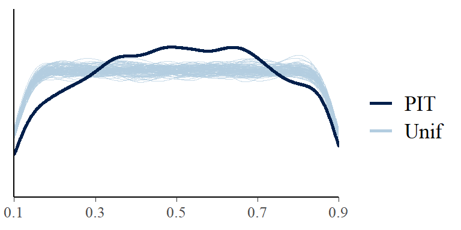

```r
psis1 <- loo1$psis_object
lw <- weights(psis1)
ppc_loo_pit_overlay(y[,1], draws$y_rep, lw)
```

Number of effective samples ratios for variables

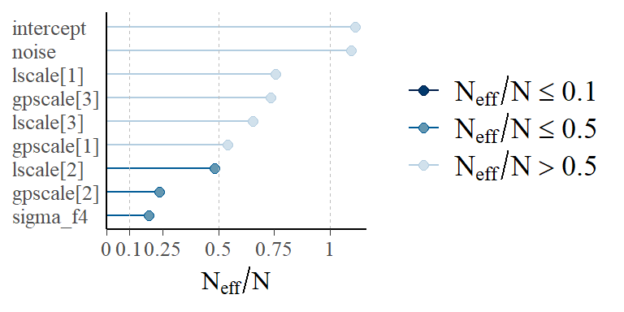

```r
ratios <- neff_ratio(fit_rstan, pars= param)
mcmc_neff(ratios, size = 2) + yaxis_text(hjust = 0)
```

Rhat statistics for sampling chains

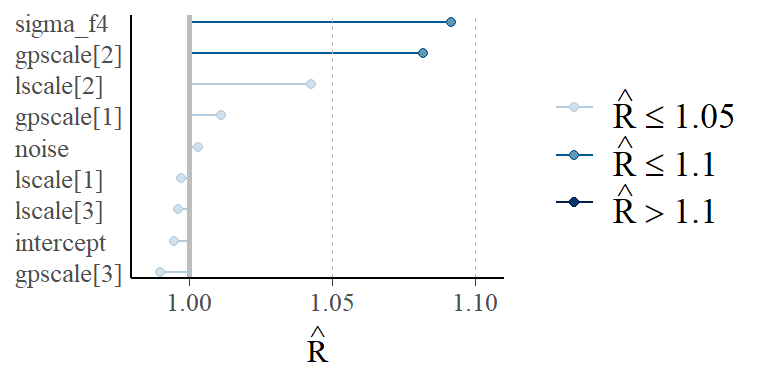

```r
rhats <- rhat(fit_rstan, pars= param)
mcmc_rhat(rhats) + yaxis_text(hjust = 0)
```

Divergence

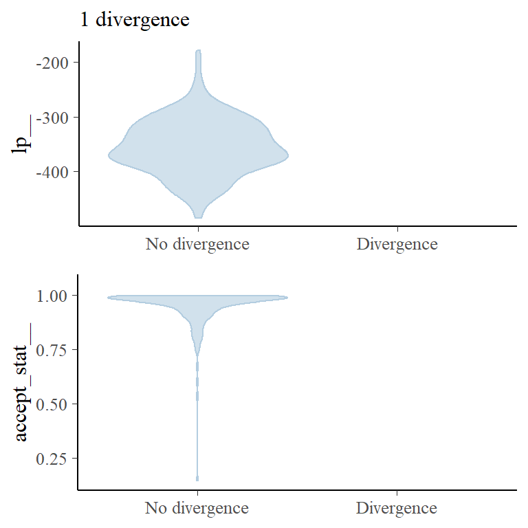

```r
mcmc_nuts_divergence(np, lp)
```

Energy

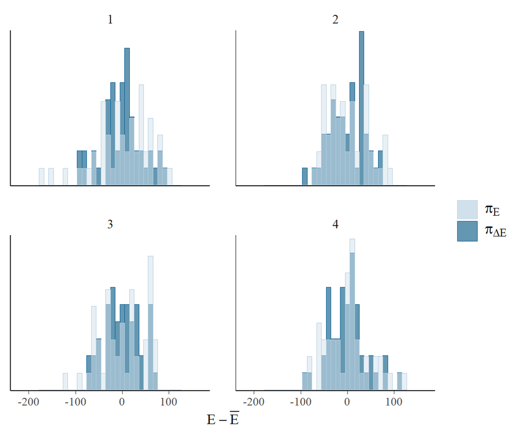

```r
mcmc_nuts_energy(np)
```

## Ploting estimated functions

Extracting estimated function components $f_1$, $f_2$, $f_3$ and $f_4$

```r
f <- summary(fit_rstan, pars = c("f"), probs = c(0.025, 0.5, 0.975), digits_summary = 4)$summary
f1 <- summary(fit_rstan, pars = c("f1"), probs = c(0.025, 0.5, 0.975), digits_summary = 4)$summary
f2 <- summary(fit_rstan, pars = c("f2"), probs = c(0.025, 0.5, 0.975), digits_summary = 4)$summary
f3 <- summary(fit_rstan, pars = c("f3"), probs = c(0.025, 0.5, 0.975), digits_summary = 4)$summary
f4 <- summary(fit_rstan, pars = c("f4"), probs = c(0.025, 0.5, 0.975), digits_summary = 4)$summary
```

#### Plot of only one year, the year 1972

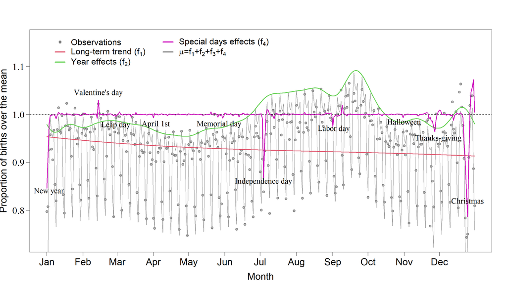

```r
data_year <- data[data$year==1972,]
ind <- data_year$id
axis_labels_at <- aggregate(data_year, by=list(data_year$month), FUN=min)$id

plot(ind, (y[ind]*std_y+m_y)/m_y, type="p", pch=21, bg=grey(0.7), cex=0.9, col=grey(0.4), xlab="", ylab="", lwd=1, ylim=c(0.73,1.16), mgp= c(2, 1, 0), frame.plot = TRUE, yaxs="r", cex.axis=1.6, cex.lab=1.6, las=1, xaxt="n", yaxt="n", fg=grey(0.5), family="serif")
axis(1, at=axis_labels_at, labels=c("Jan","Feb","Mar","Apr","May","Jun","Jul","Aug","Sep","Oct","Nov","Dec"), tick=TRUE, lty=1, mgp=c(2, 1, 0), las=1, cex.axis=1.6, font=1, col=grey(0.5), col.ticks=grey(0.3), family="")
axis(2, at=NULL, labels=TRUE, tick=TRUE, lty=1, mgp=c(3, 0.7, 0), las=1, cex.axis=1.6, font=5, col=grey(0.5), col.ticks=grey(0.3))
title(xlab ="Month", mgp= c(3, 1, 0), cex.lab=1.6, las=1)
title(ylab ="Proportion of births over the mean", mgp= c(3, 0.7, 0), cex.lab=1.6, las=1)

lines(ind, (f[ind,1]*std_y+m_y)/m_y, col=grey(0.6), lwd=1)  # f
abline(h=1, lty=2)                                                    # mean
lines(ind, (f1[ind,1]*std_y+m_y)/m_y, col=2, lwd=2)             # f1 smooth trend
lines(ind, (f2[ind,1]*std_y+m_y)/m_y, col=3, lwd=2)             # f3 year effect
lines(ind, (f4[data$day_of_year2,1][ind]*std_y+m_y)/m_y, col=6, lwd=2)          # f5 horseshoe

#labels special days
text(ind[data_year$month==1&data_year$day==1]+2, y = 0.84, labels = "New year", pos =NULL, offset = 0, family="serif", cex=1.3)
text(ind[data_year$month==2&data_year$day==14], y = 1.045, labels = "Valentine's day", pos =NULL, offset = 0, family="serif", cex=1.3)
text(ind[data_year$month==2&data_year$day==29], y = 0.978, labels = "Leap day", pos =NULL, offset = 0, family="serif", cex=1.3)
text(ind[data_year$month==4&data_year$day==1]+2, y = 0.980, labels = "April 1st", pos =NULL, offset = 0, family="serif", cex=1.3)
text(ind[data_year$month==5&data_year$day==27], y = 0.98, labels = "Memorial day", pos =NULL, offset = 0, family="serif", cex=1.3)
text(ind[data_year$month==7&data_year$day==4], y = 0.86, labels = "Independence day", pos =NULL, offset = 0, family="serif", cex=1.3)
text(ind[data_year$month==9&data_year$day==2], y = 0.97, labels = "Labor day", pos =NULL, offset = 0, family="serif", cex=1.3)
text(ind[data_year$month==10&data_year$day==30]+2, y = 0.985, labels = "Halloween", pos =NULL, offset = 0, family="serif", cex=1.3)
text(ind[data_year$month==11&data_year$day==25]+5, y = 0.95, labels = "Thanks-giving", pos =NULL, offset = 0, family="serif", cex=1.3)
text(ind[data_year$month==12&data_year$day==25], y = 0.82, labels = "Christmas", pos =NULL, offset = 0, family="serif", cex=1.3)

legend("topleft", inset=c(0.05,0.01), legend=c("Observations",TeX('Long-term trend ($f_1$)'),TeX('Year effects ($f_2$)'),TeX('Special days effects ($f_4$)'),TeX('$\\mu$=f_1+f_2+f_3+f_4$')), col=c(grey(0.5),2,3,6,grey(0.5)), lty=c(NA,1,1,1,1), pch=c(20,NA,NA,NA,NA), lwd=c(2,3,3,3,3), cex=1.4, xpd=TRUE, bty="n", y.intersp=1, x.intersp=0.8, text.font=1, ncol=2, seg.len=1.3)
```

#### Plot of all the years

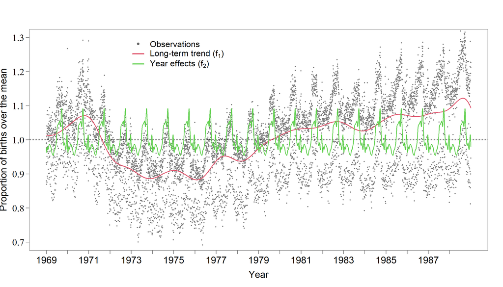

```r
ind <- data$id
labels_at = aggregate(data, by=list(data$year), FUN=min)$id
plot(ind, (y[ind]*std_y+m_y)/m_y, type="p", pch=20, bg=grey(0.4), cex=0.6, col=grey(0.5), xlab="", ylab="", lwd=1, ylim=c(0.7,1.3), mgp=c(3.5, 1, 0), frame.plot=TRUE, yaxs="r", cex.axis=1.6, cex.lab=1.6, las=1, xaxt="n", yaxt="n", fg=grey(0.5), family="serif")

axis(1, at=labels_at, c("1969","1970","1971","1972","1973","1974","1975","1976","1977","1978","1979","1980","1981","1982","1983","1984","1985","1986","1987","1988"), tick=TRUE, lty=1, mgp=c(3, 1, 0), las=1, cex.axis=1.6, font=1, col=grey(0.5), col.ticks=grey(0.3), family="")
axis(2, at=NULL, labels=TRUE, tick=TRUE, lty=1, mgp=c(3, 0.7, 0), las=1, cex.axis=1.6, font=5, col=grey(0.5), col.ticks=grey(0.3))
title(xlab="Year", mgp=c(3, 1, 0), cex.lab=1.6, las=1)
title(ylab="Proportion of births over the mean", mgp=c(3, 0.7, 0), cex.lab=1.6, las=1)

abline(h=1, lty=2)                                                              # mean
lines(ind, (f1[ind,1]*std_y+m_y)/m_y, col=2, lwd=2)             # smooth trend
lines(ind, (f2[ind,1]*std_y+m_y)/m_y, col=3, lwd=2)             # year effect

legend("topleft", inset=c(0.22,0.02), legend=c("Observations",TeX('Long-term trend ($f_1$)'),TeX('Year effects ($f_2$)')), col=c(grey(0.4),2,3,"grey"), lty=c(NA,1,1,1), pch=c(20,NA,NA,NA), lwd=c(1,3,3,3), cex=1.4, xpd=TRUE, bty="n", y.intersp=1, x.intersp=0.8, text.font=1, ncol=1, seg.len=1.5)
```

#### Plot of only the first month

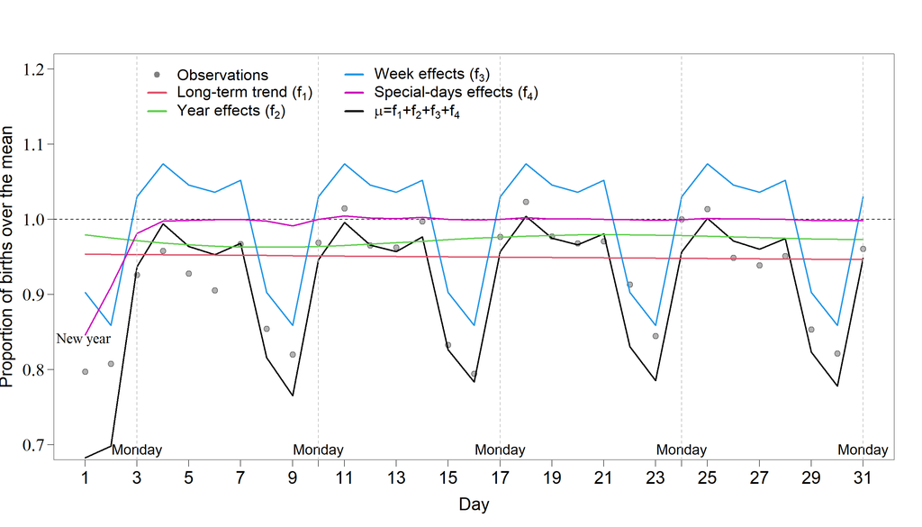

```r
data_month <- data[data$month==1&data$year==1972,]
ind <- data_month$id
axis_labels_at <- aggregate(data_month, by=list(data_month$day), FUN=min)$id

id_week <- data_month$id[data_month$day_of_week==1]

plot(ind, (y[ind]*std_y+m_y)/m_y, type="p", pch=21, bg=grey(0.7), cex=1.2, col=grey(0.4), xlab="", ylab="", lwd=1, ylim=c(0.7,1.2), mgp=c(3.5, 1, 0), frame.plot=TRUE, yaxs="r", cex.axis=1.6, cex.lab=1.6, las=1, xaxt="n", yaxt="n",fg=grey(0.5), family="serif")

axis(1, at=axis_labels_at[c(1,3,5,7,9,11,13,15,17,19,21,23,25,27,29,31)], labels=as.character(1:31)[c(1,3,5,7,9,11,13,15,17,19,21,23,25,27,29,31)], tick=TRUE, lty=1, mgp=c(3, 1, 0), las=1, cex.axis=1.6, font=1, col=grey(0.5), col.ticks=grey(0.3), family="")
axis(1, at=id_week, labels=rep(c("Monday"),5), tick=TRUE, lty=1, mgp=c(-1, -1.2, 0), las=1, cex.axis=1.3, font=1, col=grey(0.5), col.ticks=grey(0.3), family="")
axis(2, at=NULL, labels=TRUE, tick=TRUE, lty=1, mgp=c(3, 0.7, 0), las=1, cex.axis=1.6, font=5, col=grey(0.5), col.ticks=grey(0.3))
title(xlab="Day", mgp=c(3, 1, 0), cex.lab=1.6, las=1)
title(ylab="Proportion of births over the mean", mgp=c(3, 0.7, 0), cex.lab=1.6, las=1)

lines(ind, (f[ind,1]*std_y+m_y)/m_y, col="black", lwd=2)    # f
abline(h=1, lty=2)                                                            # mean
lines(ind, (f1[ind,1]*std_y+m_y)/m_y, col=2, lwd=2)           # f1 smoth trend
lines(ind, (f2[ind,1]*std_y+m_y)/m_y, col=3, lwd=2)           # f3 year effect
lines(ind, (f3[ind,1]*std_y+m_y)/m_y, col=4, lwd=2)           # f4 week effect
lines(ind, (f4[data$day_of_year2,1][ind]*std_y+m_y)/m_y, col=6, lwd=2)        # f5 horseshoe

abline(v=id_week, lty=2, col="grey")

#labels special days
text(ind[data_month$month==1&data_month$day==1]-0.05, y = 0.84, labels = "New year", pos =NULL, offset = 0, family="serif", cex=1.3, xpd=TRUE,)

legend("topleft", inset=c(0.107,0.005), legend=c("Observations",TeX('Long-term trend ($f_1$)'),TeX('Year effects ($f_2$)'),TeX('Week effects ($f_3$)'),TeX('Special-days effects ($f_4$)'),TeX('$\\mu$=f_1+f_2+f_3+f_4$')), col=c(grey(0.5),2,3,4,6,"black"), lty=c(NA,1,1,1,1,1), pch=c(20,NA,NA,NA,NA,NA), lwd=c(3,3,3,3,3,3), cex=1.4, xpd=TRUE, bty="n", y.intersp=1, x.intersp=0.8, text.font=1, ncol=2, seg.len=1.3)
```

#### Plot of the first four years

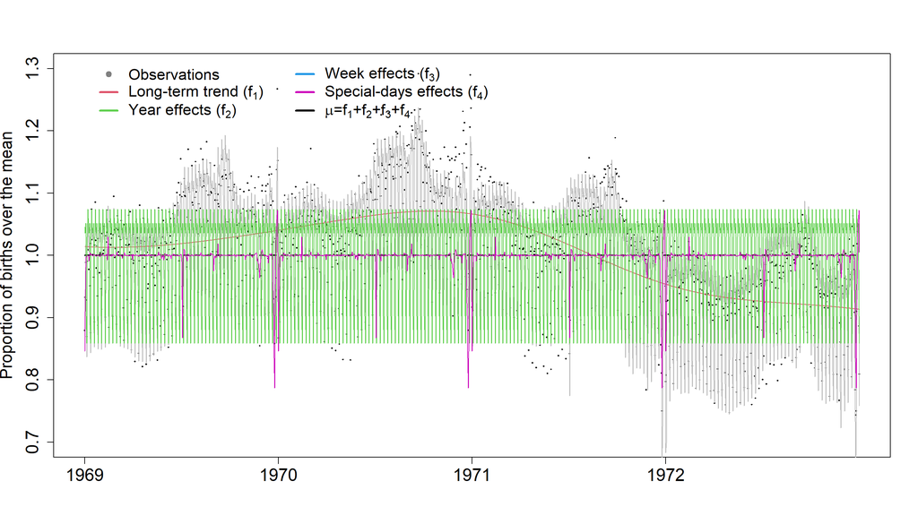

```r
data_year <- data[data$year==1969 | data$year==1970 | data$year==1971 | data$year==1972,]
ind <- data_year$id
axis_labels_at <- aggregate(data_year, by=list(data_year$year), FUN=min)$id

plot(ind, (y[ind]*std_y+m_y)/m_y, type="p", lty=1, pch=18, cex=0.4, col="black", xlab="", ylab="Proportion of births over the mean", cex.lab=1.5, cex.axis=1.6, xaxt="n", ylim=c(0.7,1.3))

axis(1, at=axis_labels_at, labels=c("1969","1970","1971","1972"), tick=TRUE, cex.axis=1.6)

lines(ind, (f[ind,1]*std_y+m_y)/m_y, col="grey", lwd=1)     # f
lines(range(ind), c(1,1), lty=2, lwd=2)                             # mean
lines(ind, (f1[ind,1]*std_y+m_y)/m_y, col=2, lwd=1)           # f1
lines(ind, (f3[ind,1]*std_y+m_y)/m_y, col=3, lwd=1)           # f3
lines(ind, (f4[data$day_of_year2,1][ind]*std_y+m_y)/m_y, col=6, lwd=1)        # f5

legend("topleft", inset=c(0.05,0.005), legend=c("Observations",TeX('Long-term trend ($f_1$)'),TeX('Year effects ($f_2$)'),TeX('Week effects ($f_3$)'),TeX('Special-days effects ($f_4$)'),TeX('$\\mu$=f_1+f_2+f_3+f_4$')), col=c(grey(0.5),2,3,4,6,"black"), lty=c(NA,1,1,1,1,1), pch=c(20,NA,NA,NA,NA,NA), lwd=c(3,3,3,3,3,3), cex=1.4, xpd=TRUE, bty="n", y.intersp=1, x.intersp=0.8, text.font=1, ncol=2, seg.len=1.3)
```